# index

Yifan Dai, Chole Su, Yilin Feng

2/20/2021

# Exploratory Analysis

## Summary

The summary information is shown below as lists. There are 183 countries in *suicide_rate_2016* data set. The country with the **lowest suicide rate** in 2016 is Antigua and Barbuda. Besides, the country that rank **#1** in happiness is Denmark with the score of 7.526. Last, we found that with the highest happiness score, the **beer consumption** is 224 Liter per Capita.

## Table

This table provides information on the *suicide rate, beer consumption, happiness score, and happiness rank* by **countries**. By creating this table, it is easier for us to organize the relationship between those factors.

Table of suicide rate, happiness score, rank, and beer consumption

| Country | suicide_rate_per_100000_population | Beer_PerCapita | Happiness.Score | Happiness.Rank |
| --- | --- | --- | --- | --- |
| Afghanistan | 4.7 | NA | NA | NA |
| Albania | 6.3 | 89 | 4.655 | 109 |
| Algeria | 3.2 | NA | NA | NA |
| Angola | 4.7 | 217 | 3.866 | 141 |
| Antigua and Barbuda | 0.5 | NA | NA | NA |
| Argentina | 9.2 | 193 | 6.650 | 26 |
| Armenia | 6.6 | 21 | 4.360 | 121 |
| Australia | 13.2 | 261 | 7.313 | 9 |
| Austria | 15.6 | 279 | 7.119 | 12 |
| Azerbaijan | 2.6 | 21 | 5.291 | 81 |
| Bahamas | 1.7 | NA | NA | NA |
| Bahrain | 5.9 | 42 | 6.218 | 42 |
| Bangladesh | 5.9 | NA | NA | NA |
| Barbados | 0.8 | NA | NA | NA |
| Belarus | 26.2 | 142 | 5.802 | 61 |
| Belgium | 20.7 | 295 | 6.929 | 18 |
| Belize | 4.7 | 263 | 5.956 | 52 |
| Benin | 9.9 | 34 | 3.484 | 153 |
| Bhutan | 11.4 | NA | NA | NA |
| Bolivia (Plurinational State of) | 12.2 | NA | NA | NA |
| Bosnia and Herzegovina | 8.8 | 76 | 5.163 | 87 |
| Botswana | 9.3 | 173 | 3.974 | 137 |
| Brazil | 6.5 | 245 | 6.952 | 17 |
| Brunei Darussalam | 4.6 | NA | NA | NA |
| Bulgaria | 11.5 | 231 | 4.217 | 129 |
| Burkina Faso | 7.7 | 25 | 3.739 | 145 |
| Burundi | 9.1 | NA | NA | NA |
| Cabo Verde | 11.3 | NA | NA | NA |
| Cambodia | 5.3 | 57 | 3.907 | 140 |
| Cameroon | 12.2 | 147 | 4.513 | 114 |

[output cut: 153 more lines]

## Chart

Chart one is a **world map** intend to show the *suicide rate per 100,000 population* around the world. From the chart we can see that **Russia** has *high level of suicide rate*, and countries in global *South* has relative **lower** suicide rate than countries in the North.

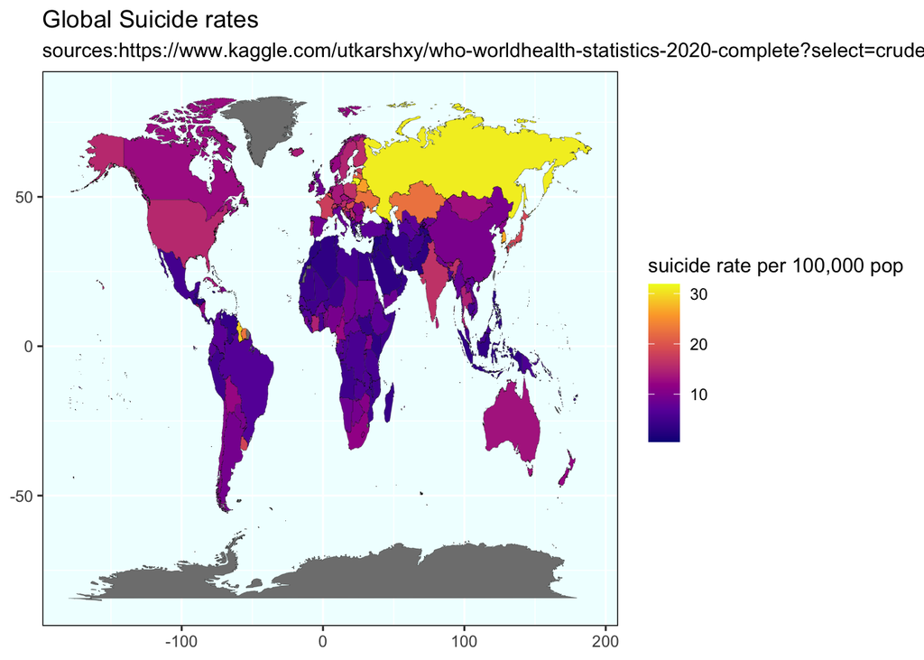

Chart two is a **scatter plot** that shows the relationship between the *average happiness score* and *liters of beer consumption per capita*. From the chart, we can see that there are some **weak positive association** between the x and the y variable. **Higher** beer consumption have **slight** correlation with **higher** average happiness score.

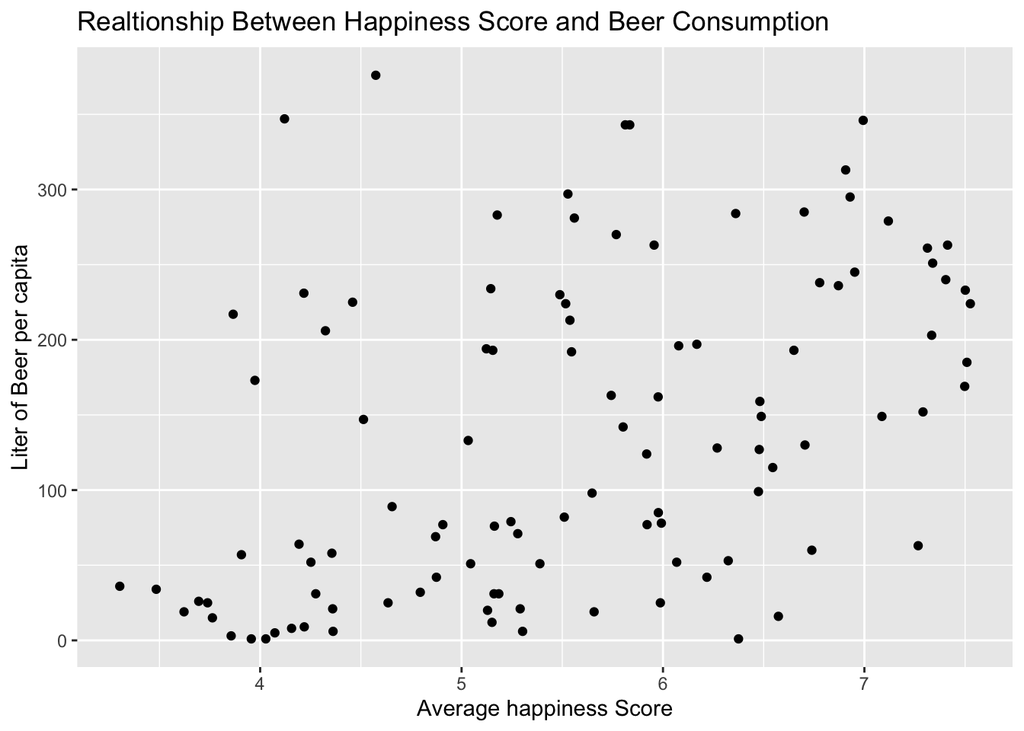

Chart three is a **bar chart** that shows the **top 20** countries with **most** *beer consumption*. We see that **Namibia** is the country with **most** beer consumption per capita.

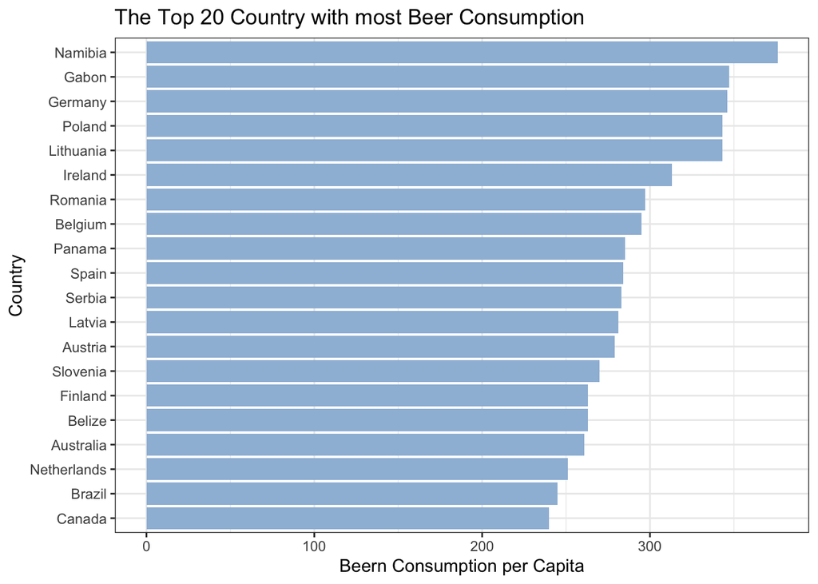